# BANA 7042 Project Part 3

Saidat Abidemi Sanni

2/23/2020

# Modeling Multinomial Data and Count Data

## Modeling Multinomial Data

### Data Import and Variable Creation

First, we import the clean data set from Part I. This data has 831 observations with 8 variables.

**Create a multinomial response variable**

A multinomial response variable is created based on the distance variable and these rules:

**Y = 1 if distance < 1000**

**Y = 2 if 1000 <= distance < 2500**

**Y = 3 otherwise**

The new multinomial response variable is named **multi_dist**. The continuous variable titled “distance” is discarded afterwards. We also assume that we do not know the order of the multinomial response variable.

For easier interpretation, we refer to Y=1 as “low distance”, Y=2 as “medium distance”, and Y=3 as “high distance”.

```r
#Create a multinomial response variable
clean_data$distance[clean_data$distance < 1000] <- 1
clean_data$distance[clean_data$distance >= 1000 &
                      clean_data$distance < 2500] <- 2
clean_data$distance[clean_data$distance > 2500] <- 3
multi_dist <- as.factor(clean_data$distance)

#Aircraft as a factor variable
clean_data$aircraft <- as.factor(clean_data$aircraft)

Data_logit <- cbind(clean_data[-8],multi_dist)
summary(Data_logit)
```

```
##    aircraft      duration         no_pasg       speed_ground
##  airbus:444   Min.   : 41.95   Min.   :29.00   Min.   : 33.57
##  boeing:387   1st Qu.:119.63   1st Qu.:55.00   1st Qu.: 66.20
##               Median :154.28   Median :60.00   Median : 79.79
##               Mean   :154.78   Mean   :60.06   Mean   : 79.54
##               3rd Qu.:189.66   3rd Qu.:65.00   3rd Qu.: 91.91
##               Max.   :305.62   Max.   :87.00   Max.   :132.78
##               NA's   :50
##    speed_air          height           pitch       multi_dist
##  Min.   : 90.00   Min.   : 6.228   Min.   :2.284   1:269
##  1st Qu.: 96.23   1st Qu.:23.530   1st Qu.:3.640   2:459
##  Median :101.12   Median :30.167   Median :4.001   3:103
##  Mean   :103.48   Mean   :30.458   Mean   :4.005
##  3rd Qu.:109.36   3rd Qu.:37.004   3rd Qu.:4.370
##  Max.   :132.91   Max.   :59.946   Max.   :5.927
##  NA's   :628
```

### Data Visualization

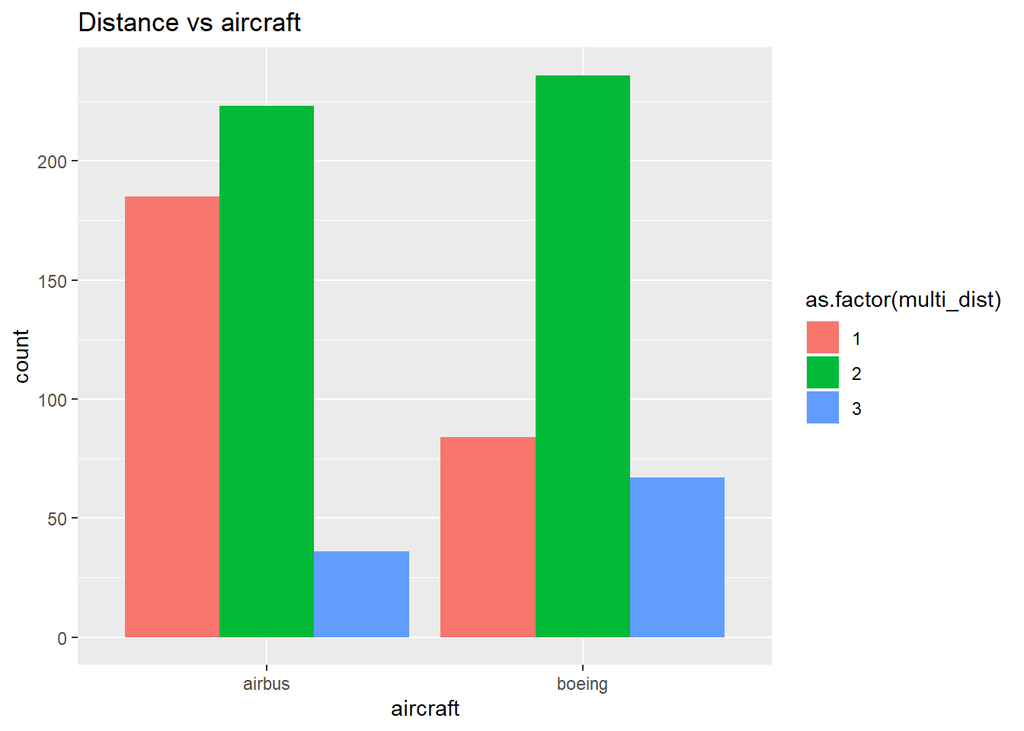

```r
library("dplyr")
library("ggplot2")

#Distance vs aircraft
ggplot(Data_logit,aes(x=aircraft,fill= as.factor(multi_dist)))+
  geom_bar(position="dodge")+ ggtitle("Distance vs aircraft")
```

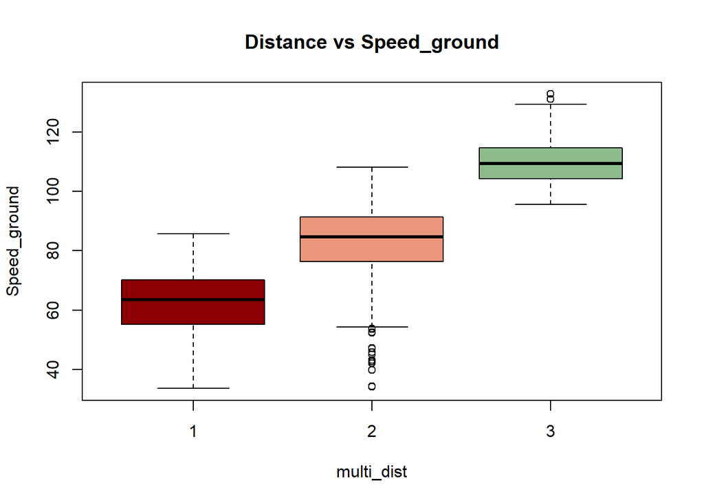

```r
#Distance vs speed_ground
plot(speed_ground~multi_dist,data = Data_logit,col=colors()[100:102],
     ylab="Speed_ground",
     main="Distance vs Speed_ground")
```

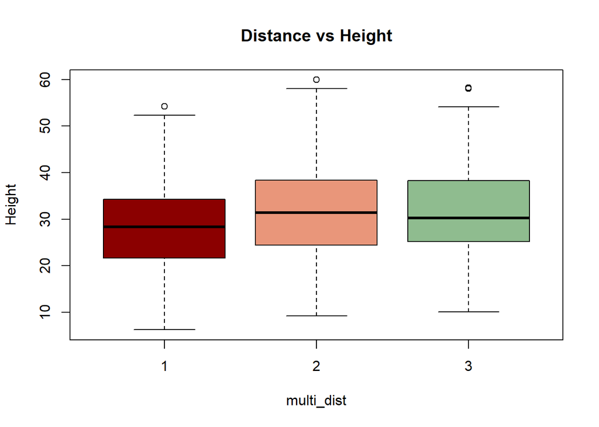

```r
#Distance vs height
plot(height~multi_dist,data = Data_logit,col=colors()[100:102],
     ylab="Height",
     main="Distance vs Height")
```

### Full Model

First, we fit a multinomial model with all of the variables. However, we observe that the coefficients and standard errors aren’t based on the comparison of the two levels of the multinomial response variable with the reference category.

After some investigation, I realized that speed_air is the problematic variable. There seems to be a problem of perfect prediction. That is, speed_air seems to be only associated with category 2 and 3 of the response variable. Hence, speed_air is excluded from the model.

We aren’t losing a lot of information by the exclusion because the model still includes speed_ground which is highly correlated with speed_air.

```r
library("nnet")
mmod1a <- multinom(multi_dist~aircraft+duration+no_pasg+speed_ground
                   +speed_air+height+pitch, Data_logit)
summary(mmod1a)
```

```
## Call:
## multinom(formula = multi_dist ~ aircraft + duration + no_pasg +
##     speed_ground + speed_air + height + pitch, data = Data_logit)
##
## Coefficients:
##                       Values  Std. Err.
## (Intercept)    -1.962720e+02 0.04010950
## aircraftboeing  8.780687e+00 0.96455561
## duration        3.035686e-04 0.01047097
## no_pasg        -7.356207e-02 0.06707488
## speed_ground   -2.253815e-01 0.37344471
## speed_air       1.984274e+00 0.39729688
## height          4.223513e-01 0.05903968
## pitch           1.468367e+00 0.89109555
##
## Residual Deviance: 32.90946
## AIC: 48.90946
```

```r
mmod1b <- multinom(multi_dist~ aircraft+duration+no_pasg+speed_ground
                   +height+pitch,Data_logit)
summary(mmod1b)
```

```
## Call:
## multinom(formula = multi_dist ~ aircraft + duration + no_pasg +
##     speed_ground + height + pitch, data = Data_logit)
##
## Coefficients:
##   (Intercept) aircraftboeing     duration     no_pasg speed_ground    height
## 2    -20.0985       4.084558 -0.003528410 -0.01864576    0.2444092 0.1564499
## 3   -134.9445       9.066761  0.001835174 -0.01119463    1.2236524 0.3909273
##        pitch
## 2 -0.4055170
## 3  0.8773354
##
## Std. Errors:
##   (Intercept) aircraftboeing    duration    no_pasg speed_ground     height
## 2  2.33164518      0.4370675 0.002795548 0.01790935   0.02045739 0.01860185
## 3  0.04012959      0.8816880 0.008101225 0.05827170   0.04073362 0.04903549
##       pitch
## 2 0.2798748
## 3 0.7670509
##
## Residual Deviance: 397.4979
## AIC: 425.4979
```

### Model Selection

**Best subset variable selection**

Next, we consider the best subset variable selection technique to select the best model using the BIC criterion. This is considered because BIC gives a simpler model, with less complexity.

Based on the BIC criterion, the reduced model with the lowest BIC value includes the following variables: aircraft, speed_ground,and height as shown in the figure below.

```r
#Best subset variable selection
require(leaps)
Model_best <- regsubsets(multi_dist~.-speed_air,data = Data_logit[,-8],
                         nbest=2, nvmax=14)
summary(Model_best)
```

```
## Subset selection object
## Call: regsubsets.formula(multi_dist ~ . - speed_air, data = Data_logit[,
##     -8], nbest = 2, nvmax = 14)
## 6 Variables  (and intercept)
##                Forced in Forced out
## aircraftboeing     FALSE      FALSE
## duration           FALSE      FALSE
## no_pasg            FALSE      FALSE
## speed_ground       FALSE      FALSE
## height             FALSE      FALSE
## pitch              FALSE      FALSE
## 2 subsets of each size up to 6
## Selection Algorithm: exhaustive
##          aircraftboeing duration no_pasg speed_ground height pitch
## 1  ( 1 ) " "            " "      " "     "*"          " "    " "
## 1  ( 2 ) "*"            " "      " "     " "          " "    " "
## 2  ( 1 ) "*"            " "      " "     "*"          " "    " "
## 2  ( 2 ) " "            " "      " "     "*"          "*"    " "
## 3  ( 1 ) "*"            " "      " "     "*"          "*"    " "
## 3  ( 2 ) "*"            " "      " "     "*"          " "    "*"
## 4  ( 1 ) "*"            " "      " "     "*"          "*"    "*"
## 4  ( 2 ) "*"            "*"      " "     "*"          "*"    " "
## 5  ( 1 ) "*"            "*"      " "     "*"          "*"    "*"
## 5  ( 2 ) "*"            " "      "*"     "*"          "*"    "*"
## 6  ( 1 ) "*"            "*"      "*"     "*"          "*"    "*"
```

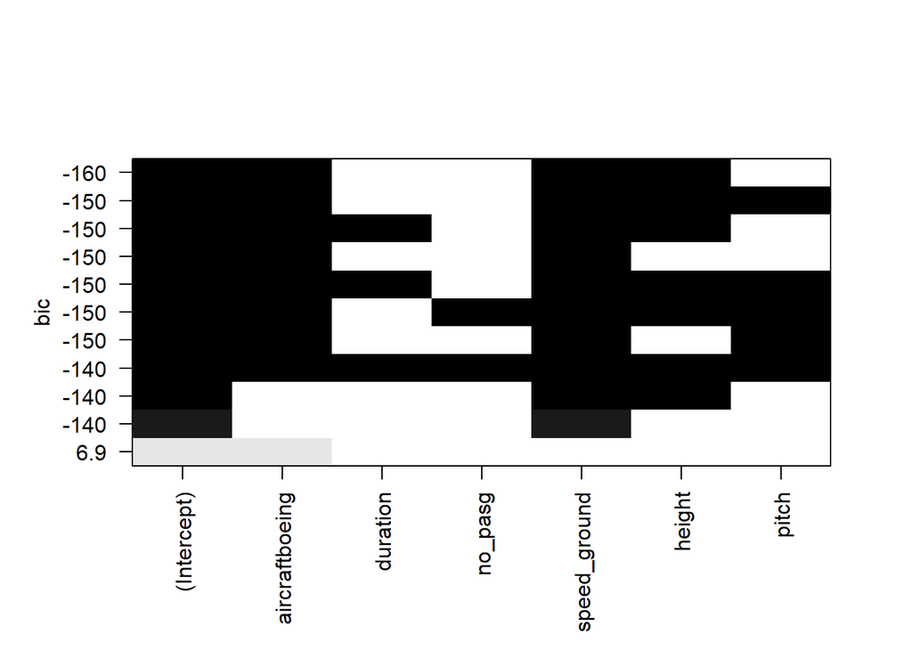

```r
plot(Model_best,scale="bic")
```

**Reduced Model: Selected model using Best subset variable selection**

Next, we create a model with the variables selected by the best subset technique. This is called the **Reduced Model**

```r
#Reduced model
reduced_model <- multinom(multi_dist~ aircraft+speed_ground+height,
                          data = Data_logit)
summary(reduced_model)
```

```
## Call:
## multinom(formula = multi_dist ~ aircraft + speed_ground + height,
##     data = Data_logit)
##
## Coefficients:
##   (Intercept) aircraftboeing speed_ground    height
## 2   -23.28484       3.982905    0.2472743 0.1467859
## 3  -126.43265       9.040905    1.1756019 0.3782799
##
## Std. Errors:
##   (Intercept) aircraftboeing speed_ground     height
## 2  1.88720542      0.4027433   0.01980816 0.01714538
## 3  0.04519312      0.7502719   0.01276020 0.03604886
##
## Residual Deviance: 430.9527
## AIC: 446.9527
```

```r
BIC(reduced_model)
```

```
## [1] 484.7338
```

**Model Comparison**

We compare the full model and the reduced model (selected using the best subset variable selection procedure). The reduced model has a lower BIC compared to the full model. The chi-square test is also employed in selecting the best model between the full and the reduced model.

**Null hypothesis: No difference between the two models**

**Alternative hypothesis: The reduced/smaller model is sufficient**

```r
#model comparison based on BIC
BIC(mmod1b); BIC(reduced_model)
```

```
## [1] 490.746
```

```
## [1] 484.7338
```

```r
#model comparison based on the significance
#Difference between degrees of freedom
deviance(reduced_model) - deviance(mmod1b)
```

```
## [1] 33.45479
```

```r
#difference between degrees of freedom
mmod1b$edf - reduced_model$edf
```

```
## [1] 6
```

```r
###Chi^2 test
pchisq(deviance(reduced_model) - deviance(mmod1b), mmod1b$edf -
         reduced_model$edf, lower=F)
```

```
## [1] 8.570841e-06
```

### Best Model & Model Performance

The selected model does a good job with in-sample classification and prediction given that the misclassification rate is 0.0975, which is very low.

**Best Model**

```r
#model
best_model <- multinom(multi_dist~ aircraft+speed_ground+height,
                       data = Data_logit)
summary(best_model)
```

```
## Call:
## multinom(formula = multi_dist ~ aircraft + speed_ground + height,
##     data = Data_logit)
##
## Coefficients:
##   (Intercept) aircraftboeing speed_ground    height
## 2   -23.28484       3.982905    0.2472743 0.1467859
## 3  -126.43265       9.040905    1.1756019 0.3782799
##
## Std. Errors:
##   (Intercept) aircraftboeing speed_ground     height
## 2  1.88720542      0.4027433   0.01980816 0.01714538
## 3  0.04519312      0.7502719   0.01276020 0.03604886
##
## Residual Deviance: 430.9527
## AIC: 446.9527
```

**Predicted probabilities**

```r
#predicted probabilities
pred_lprob <- predict(reduced_model,Data_logit, type = "probs")
head(pred_lprob, 10)
```

```
##               1            2            3
## 1  2.403400e-09 0.0002163023 9.997837e-01
## 2  3.061082e-06 0.0620059283 9.379910e-01
## 3  2.697197e-01 0.7302803474 6.003268e-13
## 4  1.609247e-03 0.9983785196 1.223322e-05
## 5  4.347542e-01 0.5652457974 3.586254e-16
## 6  4.981863e-03 0.9950181312 6.094404e-09
## 7  9.100954e-01 0.0899046010 5.184192e-20
## 8  9.118276e-01 0.0881724148 2.071558e-19
## 9  8.941804e-04 0.9990804474 2.537216e-05
## 10 2.021342e-01 0.7978658138 8.148886e-15
```

**Confusion Matrix**

```r
#confusion matrix
predicted_class <- predict (reduced_model,Data_logit)
table(predicted_class, Data_logit$multi_dist, dnn = c("True", "Predicted"))
```

```
##     Predicted
## True   1   2   3
##    1 232  34   0
##    2  37 421   6
##    3   0   4  97
```

**Misclassification Rate**

```r
#misclassification rate
mean(as.character(predicted_class) != as.character(Data_logit$multi_dist),
     na.rm = TRUE)
```

```
## [1] 0.09747292
```

## Q1: Presentation to the FAA Agent

**Note:** For easier interpretation, the 3 levels of the multinomial response variable “landing distance” are refered to as follows: Y=1 as “low distance”, Y=2 as “medium distance”, and Y=3 as “high distance”.

**Executive summary**

**Model**

```r
#model
best_model <- multinom(multi_dist~ aircraft+speed_ground+height,
                       data = Data_logit)
summary(best_model)
```

```
## Call:
## multinom(formula = multi_dist ~ aircraft + speed_ground + height,
##     data = Data_logit)
##
## Coefficients:
##   (Intercept) aircraftboeing speed_ground    height
## 2   -23.28484       3.982905    0.2472743 0.1467859
## 3  -126.43265       9.040905    1.1756019 0.3782799
##
## Std. Errors:
##   (Intercept) aircraftboeing speed_ground     height
## 2  1.88720542      0.4027433   0.01980816 0.01714538
## 3  0.04519312      0.7502719   0.01276020 0.03604886
##
## Residual Deviance: 430.9527
## AIC: 446.9527
```

**Association between the significant factors and the landing process**

The figures below show the association between the significant factors and the 3 levels of the multinomial response variable “landing distance”.

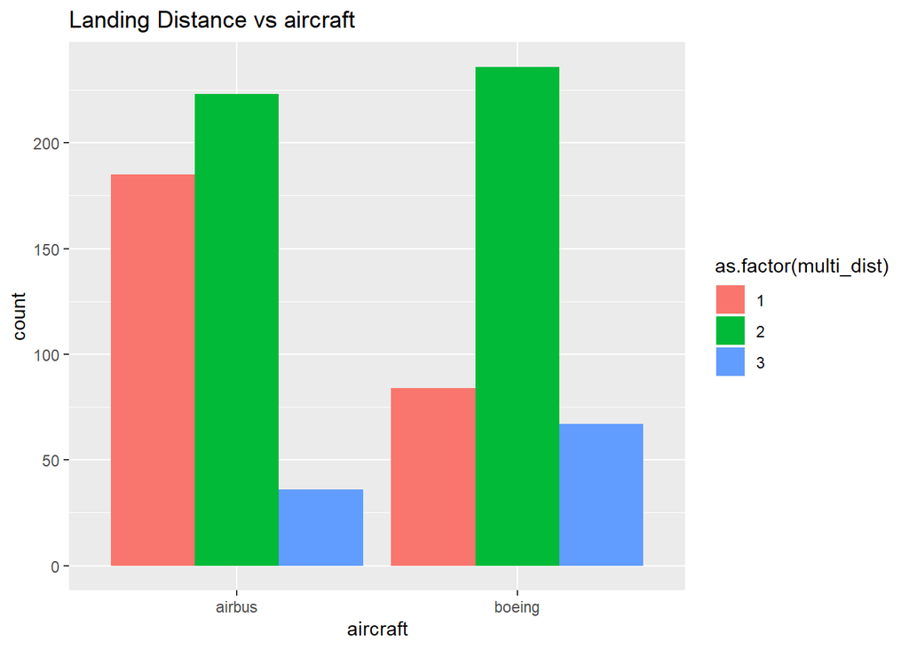

```r
#Landing Distance Categories vs aircraft
ggplot(Data_logit,aes(x=aircraft,fill= as.factor(multi_dist)))+
  geom_bar(position="dodge")+ ggtitle("Landing Distance vs aircraft")
```

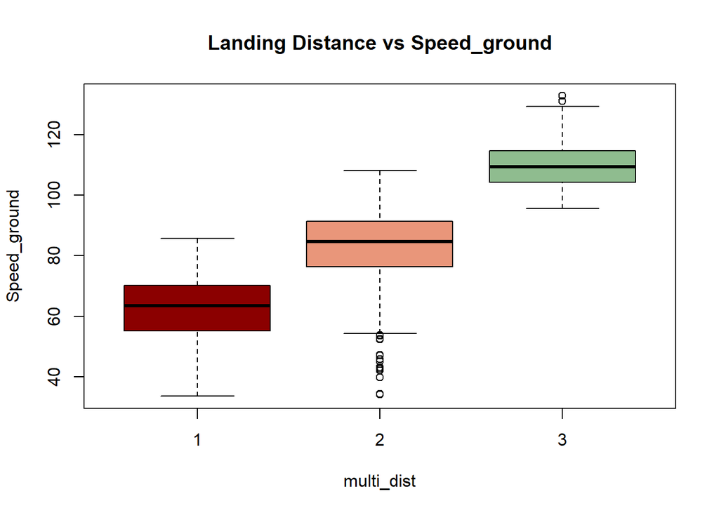

```r
#Landing Distance Categories vs speed_ground
plot(speed_ground~multi_dist,data = Data_logit,col=colors()[100:102],
     ylab="Speed_ground",
     main="Landing Distance vs Speed_ground")
```

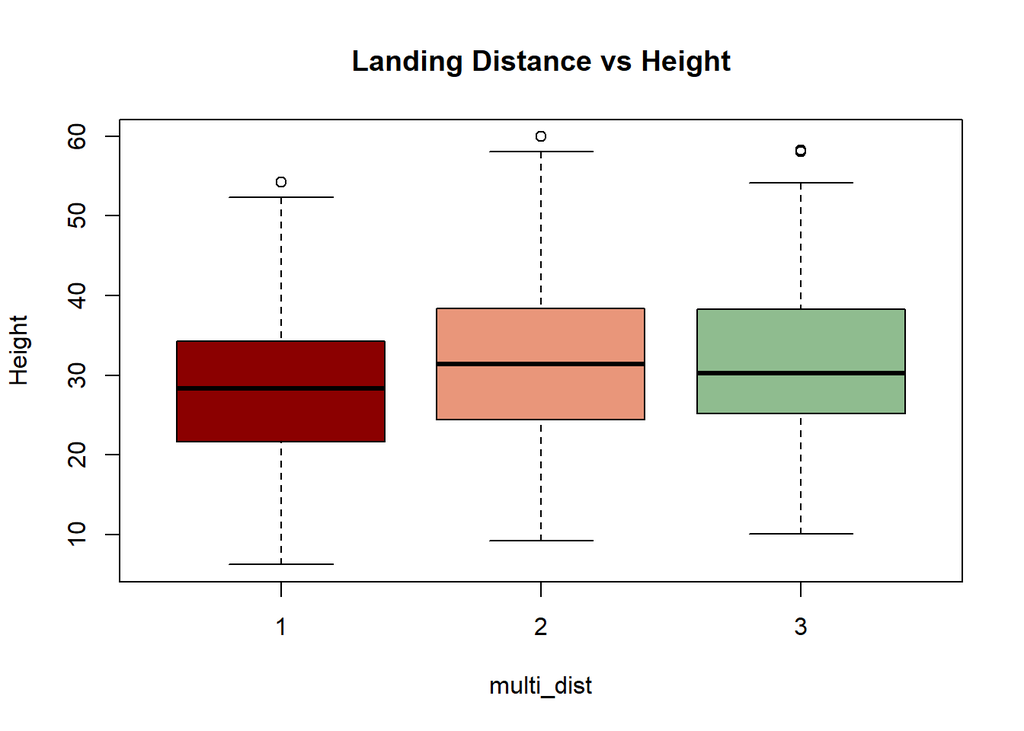

```r
#Landing Distance categories vs height
plot(height~multi_dist,data = Data_logit,col=colors()[100:102],
     ylab="Height",
     main="Landing Distance vs Height")
```

**Confusion Matrix and Misclassification rate of the model**

```r
#confusion matrix
predicted_class <- predict (best_model,Data_logit)
table(predicted_class, Data_logit$multi_dist, dnn = c("True", "Predicted"))
```

```
##     Predicted
## True   1   2   3
##    1 232  34   0
##    2  37 421   6
##    3   0   4  97
```

```r
#misclassification rate
mean(as.character(predicted_class) != as.character(Data_logit$multi_dist),
     na.rm = TRUE)
```

```
## [1] 0.09747292
```

## Q2: Modeling count Data (No of Passengers)

**Given that the number of passenger is a count data, it can be modeled using the poisson distribution**

### Fit a GLM

The model indicates that none of the variables in the dataset have significant impact on the number of passengers.

We consider further exploration by observing the correlation between the predictor variables and the response variable.

```r
Data <- read.csv("clean_data.csv")
mmod_pass <- glm(no_pasg~., family=poisson, Data[,-1])
summary(mmod_pass)
```

```
##
## Call:
## glm(formula = no_pasg ~ ., family = poisson, data = Data[, -1])
##
## Deviance Residuals:
##      Min        1Q    Median        3Q       Max
## -2.63995  -0.54433   0.06167   0.55223   2.49267
##
## Coefficients:
##                  Estimate Std. Error z value Pr(>|z|)
## (Intercept)     3.563e+00  4.631e-01   7.694 1.43e-14 ***
## aircraftboeing  2.814e-02  3.687e-02   0.763    0.445
## duration       -1.607e-04  1.963e-04  -0.819    0.413
## speed_ground    4.506e-04  6.170e-03   0.073    0.942
## speed_air       7.074e-03  8.668e-03   0.816    0.414
## height          1.206e-03  1.381e-03   0.873    0.383
## pitch          -5.763e-03  1.793e-02  -0.321    0.748
## distance       -9.215e-05  6.988e-05  -1.319    0.187
## ---
## Signif. codes:  0 '***' 0.001 '**' 0.01 '*' 0.05 '.' 0.1 ' ' 1
##
## (Dispersion parameter for poisson family taken to be 1)
##
##     Null deviance: 162.74  on 194  degrees of freedom
## Residual deviance: 159.57  on 187  degrees of freedom
##   (636 observations deleted due to missingness)
## AIC: 1330.9
##
## Number of Fisher Scoring iterations: 4
```

### Correlation

We observe the presence of high correlation between the following pairs: speed_ground and speed_air; speed_ground and distance; speed_air and distance. However, speed_ground and speed_air have no relationship with the number of passengers on board. In addition, all of the other variables have very weak relationship with the number of passenger. This confirms why none of the predictor variables were significant in the model.

Hence, I conclude that with the number of passenger being modeled using a poisson distribution, none of the variables in the FAA data set are useful in predicting the number of passengers on board.

```r
Data1 <- na.omit(Data[,-1])
round(cor(Data1[sapply(Data1, is.numeric)]),2)
```

```
##              duration no_pasg speed_ground speed_air height pitch distance
## duration         1.00   -0.07         0.02      0.04   0.07 -0.06     0.05
## no_pasg         -0.07    1.00         0.00      0.00  -0.01 -0.04    -0.03
## speed_ground     0.02    0.00         1.00      0.99  -0.10 -0.06     0.93
## speed_air        0.04    0.00         0.99      1.00  -0.09 -0.05     0.94
## height           0.07   -0.01        -0.10     -0.09   1.00 -0.03     0.06
## pitch           -0.06   -0.04        -0.06     -0.05  -0.03  1.00     0.03
## distance         0.05   -0.03         0.93      0.94   0.06  0.03     1.00
```

### Conclusion and Recommendation

Given the conclusion that none of the variables in the FAA data set are useful in predicting the number of passengers on board, I would recommend that the FAA agent take a look at other variables such as ticket price, season, take-off location, destination of the aircraft, weather, discounts, and other events that may influence the number of passengers on board.